# Регрессия

Sergey

2025-01-19

# Домашнее задание по регрессионному анализу

**Гликированный гемоглобин (HbA1c)** — это показатель, отражающий средний уровень глюкозы в крови за последние 2–3 месяца. Чем выше HbA1c, тем выше риск развития осложнений сахарного диабета.

**Физическая активность (ФА)**, согласно многим исследованиям, может способствовать снижению уровня глюкозы в крови и, следовательно, уменьшению уровня HbA1c. Однако, чтобы правильно выделить именно причинно-следственную связь, необходимо корректировать влияние различных ковариат, которые могут выступать в роли конфаундеров, медиаторов или коллайдеров (согласно анализу DAG — направленного ациклического графа).

Ниже мы пошагово рассмотрим:

1. Как сформировать показатель физической активности из имеющихся переменных.
2. Какие ковариаты (демографические или клинические) включить в модель регрессии.
3. Как проверить, действительно ли физическая активность связана с более низким уровнем HbA1c (путём регрессионного анализа).
4. Как интерпретировать полученные результаты (точечные и интервальные оценки, проверку статистических гипотез и клиническую значимость).

## Импорт данных и data preprocessing (Шаги 1–2)

1. Загружаем Excel-файл HW_data.xlsx, переводим в факторы нужные столбцы (пол, образование, курение и т.д.), проверяем пропуски.
2. Создаём новую переменную total_pa (total physical activity), суммируя, к примеру, время разных типов физической активности.

### Загрузка данных

### Препроцессинг данных

```
## Проверка пропущенных значений:
```

```
##     SEQN DMDEDUC2 DMDHHSIZ DMDHHSZA DMDHHSZB DMDHHSZE DMDMARTL INDFMIN2
##        0        0        0        0        0        0        0        0
## RIAGENDR RIDAGEYR RIDRETH3 DR1TALCO DR1TCHOL DR1TFIBE DR1TKCAL DR1TMFAT
##        0        0        0        0        0        0        0        0
## DR1TPFAT DR1TSFAT DR1TSUGR DR1TTFAT   DRD340   DRD360 DRQSDIET  DRQSDT1
##        0        0        0        0        0        0        0        0
## DRQSDT10  DRQSDT2  DRQSDT3  DRQSDT4  DRQSDT7  DRQSDT8  DRQSDT9 DRQSDT91
##        0        0        0        0        0        0        0        0
##   BMXBMI    BMXHT    BMXWT    LBXGH   BPQ020  BPQ050A   MCQ010   MCQ035
##        0        0        0        0        0        0        0        0
##  MCQ160B  MCQ160C  MCQ160E  MCQ160F  MCQ160M  MCQ160O  MCQ170M   MCQ220
##        0        0        0        0        0        0        0        0
##   PAD615   PAD630   PAD645   PAD660   PAD675   PAD680   PAQ605   PAQ610
##        0        0        0        0        0        0        0        0
##   PAQ620   PAQ625   PAQ635   PAQ640   PAQ650   PAQ655   PAQ665   PAQ670
##        0        0        0        0        0        0        0        0
##   DIQ010   DIQ070   SMQ020   SMQ040   ALQ101  ALQ120Q  ALQ120U   ALQ130
##        0        0        0        0        0        0        0        0
##    BPXDI    BPXSY total_pa
##        0        0        0
```

```
##
## Структура (частичная) данных:
```

```
## tibble [916 × 7] (S3: tbl_df/tbl/data.frame)
##  $ LBXGH   : num [1:916] 6.2 5.6 5.2 5.8 5.2 5.3 5 6.4 4.8 5.6 ...
##  $ total_pa: num [1:916] 520 795 660 540 660 420 825 690 300 250 ...
##  $ RIDAGEYR: num [1:916] 76 44 30 80 20 52 22 45 25 62 ...
##  $ RIAGENDR: Factor w/ 2 levels "Male","Female": 2 1 1 1 1 1 1 2 1 2 ...
##  $ DMDEDUC2: Factor w/ 5 levels "<9th grade","9-11th grade",..: 4 5 3 4 3 3 4 5 5 1 ...
##  $ SMQ020  : Factor w/ 2 levels "No","Yes": 1 1 2 1 1 1 2 1 1 1 ...
##  $ BMXBMI  : num [1:916] 27.7 24.7 26.1 30.2 28.1 23.5 30.6 28.3 20.8 23.6 ...
```

## Эксплораторный анализ (EDA, Шаг 3)

1. Считаем описательные статистики (минимум, максимум, медиану, среднее, SD и т.д.).
2. Строим гистограммы для первичной оценки распределений.
3. Смотрим таблицы частот для категориальных переменных.

```
##
## Описательная статистика для численных переменных:
```

```
##       SEQN          DMDHHSIZ        DMDHHSZA         DMDHHSZB
##  Min.   :73557   Min.   :1.000   Min.   :0.0000   Min.   :0.0000
##  1st Qu.:76159   1st Qu.:2.000   1st Qu.:0.0000   1st Qu.:0.0000
##  Median :78868   Median :2.000   Median :0.0000   Median :0.0000
##  Mean   :78750   Mean   :2.892   Mean   :0.1812   Mean   :0.3843
##  3rd Qu.:81432   3rd Qu.:4.000   3rd Qu.:0.0000   3rd Qu.:0.0000
##  Max.   :83724   Max.   :7.000   Max.   :3.0000   Max.   :4.0000
##     DMDHHSZE         DMDMARTL        INDFMIN2         RIDAGEYR
##  Min.   :0.0000   Min.   :1.000   Min.   : 1.000   Min.   :20.0
##  1st Qu.:0.0000   1st Qu.:1.000   1st Qu.: 5.000   1st Qu.:45.0
##  Median :1.0000   Median :1.000   Median : 7.000   Median :56.0
##  Mean   :0.7434   Mean   :2.267   Mean   : 7.483   Mean   :54.7
##  3rd Qu.:1.0000   3rd Qu.:3.000   3rd Qu.:11.000   3rd Qu.:67.0
##  Max.   :3.0000   Max.   :6.000   Max.   :12.000   Max.   :80.0
##     RIDRETH3        DR1TALCO         DR1TCHOL         DR1TFIBE
##  Min.   :1.000   Min.   :  0.00   Min.   :   0.0   Min.   :  1.00
##  1st Qu.:3.000   1st Qu.:  0.00   1st Qu.: 134.0   1st Qu.:  9.70
##  Median :3.000   Median :  0.00   Median : 233.0   Median : 15.00
##  Mean   :3.249   Mean   : 11.49   Mean   : 312.1   Mean   : 17.52
##  3rd Qu.:4.000   3rd Qu.:  8.05   3rd Qu.: 426.0   3rd Qu.: 22.50
##  Max.   :7.000   Max.   :591.40   Max.   :2584.0   Max.   :107.00
##     DR1TKCAL        DR1TMFAT          DR1TPFAT          DR1TSFAT
##  Min.   :  358   Min.   :  0.921   Min.   :  0.223   Min.   :  1.374
##  1st Qu.: 1425   1st Qu.: 16.653   1st Qu.:  9.991   1st Qu.: 14.754
##  Median : 1936   Median : 25.403   Median : 16.377   Median : 23.877
##  Mean   : 2140   Mean   : 28.602   Mean   : 19.768   Mean   : 26.455
##  3rd Qu.: 2626   3rd Qu.: 36.874   3rd Qu.: 24.846   3rd Qu.: 34.593
##  Max.   :12108   Max.   :185.833   Max.   :135.346   Max.   :177.467
##     DR1TSUGR         DR1TTFAT          DRD340          DRD360
##  Min.   :  2.75   Min.   :  3.93   Min.   :1.000   Min.   :1.000
##  1st Qu.: 56.29   1st Qu.: 49.53   1st Qu.:1.000   1st Qu.:1.000
##  Median : 90.45   Median : 73.96   Median :1.000   Median :1.000
##  Mean   :107.66   Mean   : 82.59   Mean   :1.477   Mean   :1.295
##  3rd Qu.:142.70   3rd Qu.:105.91   3rd Qu.:2.000   3rd Qu.:2.000
##  Max.   :835.70   Max.   :548.38   Max.   :2.000   Max.   :9.000
##     DRQSDIET       DRQSDT1         DRQSDT10        DRQSDT2         DRQSDT3
##  Min.   :1.00   Min.   :1.000   Min.   :1.000   Min.   :1.000   Min.   :1.000
##  1st Qu.:2.00   1st Qu.:2.000   1st Qu.:2.000   1st Qu.:2.000   1st Qu.:2.000
##  Median :2.00   Median :2.000   Median :2.000   Median :2.000   Median :2.000
##  Mean   :1.83   Mean   :1.931   Mean   :1.996   Mean   :1.977   Mean   :1.977
```

[output cut: 71 more lines]

```
##  Max.   :2.000   Max.   :3.000   Max.   :2.000   Max.   :350.000
##     ALQ120U          ALQ130            BPXDI            BPXSY
##  Min.   :1.000   Min.   :  0.000   Min.   :  0.00   Min.   : 64.67
##  1st Qu.:1.000   1st Qu.:  0.000   1st Qu.: 64.00   1st Qu.:115.17
##  Median :1.000   Median :  1.000   Median : 71.33   Median :124.67
##  Mean   :1.572   Mean   :  2.836   Mean   : 70.15   Mean   :126.50
##  3rd Qu.:2.000   3rd Qu.:  2.000   3rd Qu.: 78.00   3rd Qu.:136.67
##  Max.   :3.000   Max.   :999.000   Max.   :110.00   Max.   :202.67
##     total_pa
##  Min.   :  30.0
##  1st Qu.: 390.0
##  Median : 555.0
##  Mean   : 586.7
##  3rd Qu.: 720.0
##  Max.   :9999.0
```

```
##
## Частоты категориальных переменных:
```

```
##
## DMDEDUC2:
##
##   <9th grade 9-11th grade  HS Grad/GED Some College College Grad
##           54          119          203          297          243
##
## RIAGENDR:
##
##   Male Female
##    539    377
##
## SMQ020:
##
##  No Yes
## 488 428
```

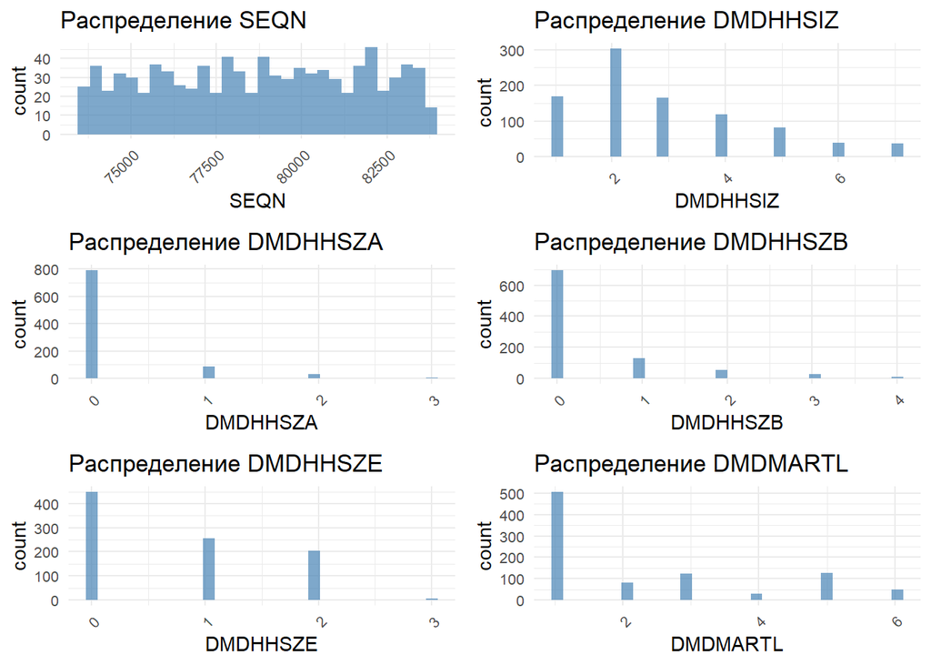

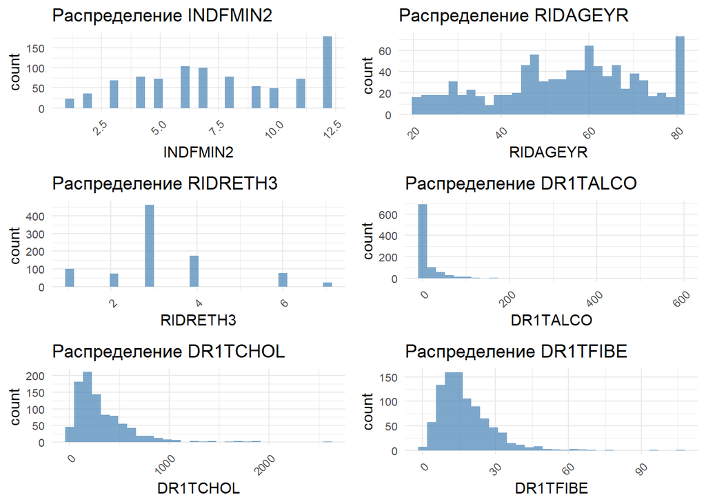

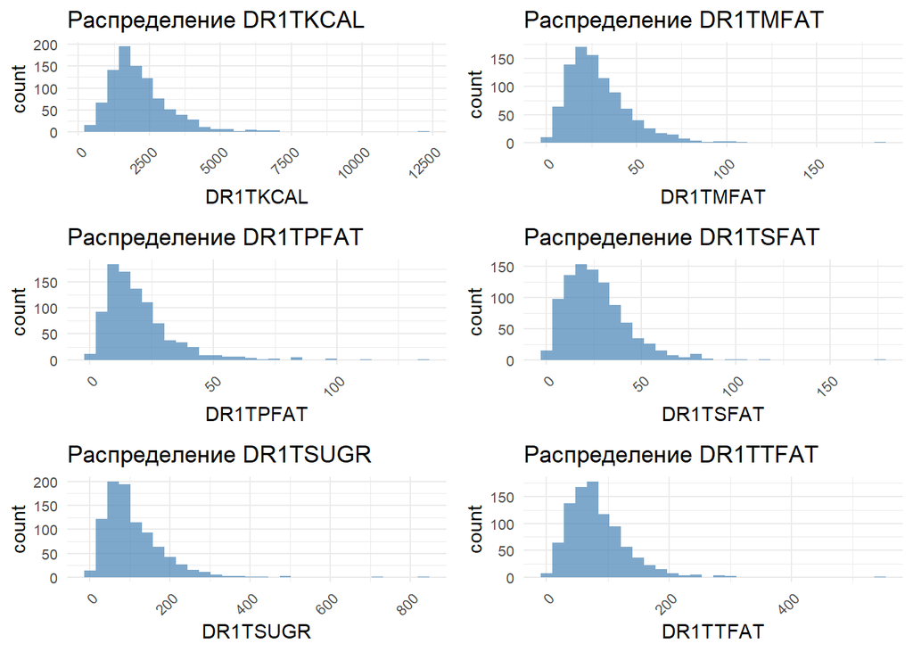

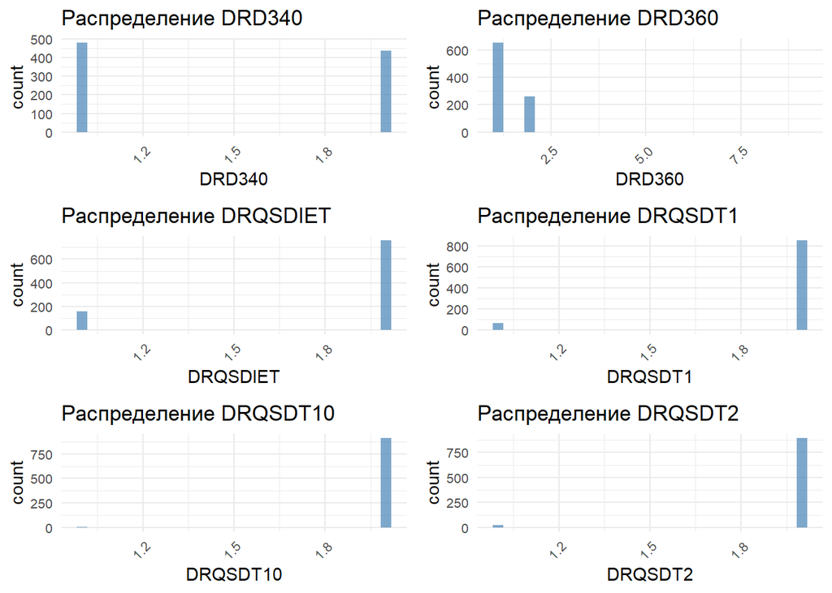

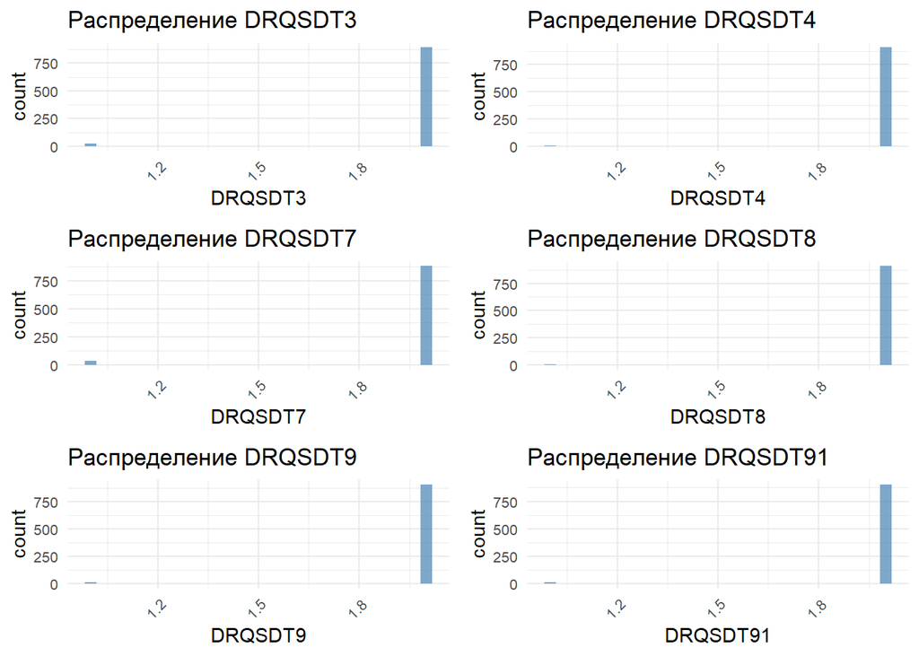

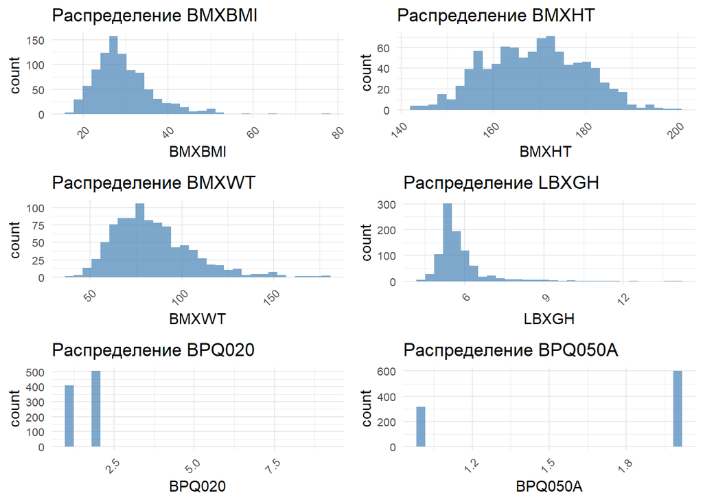

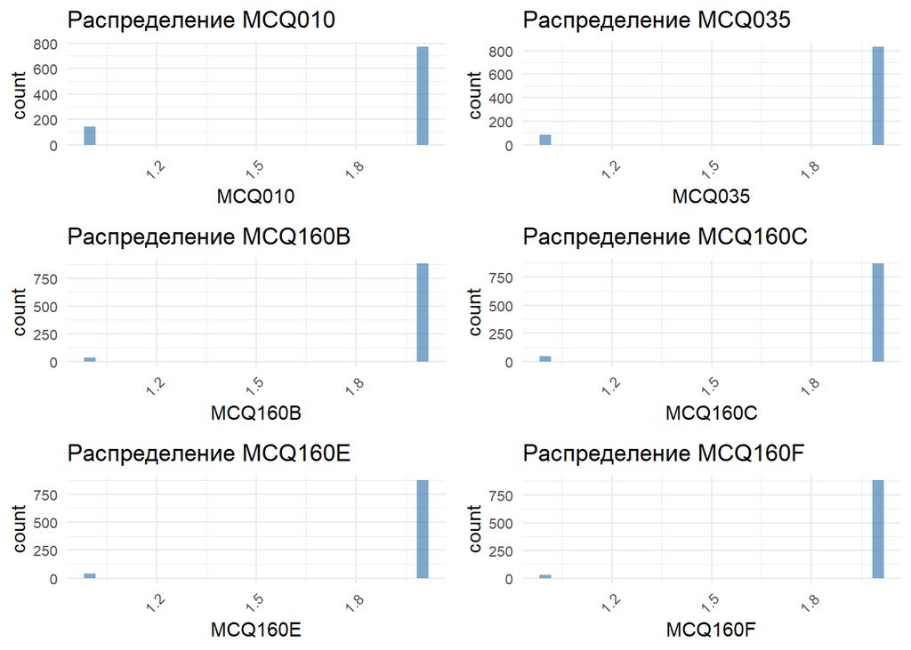

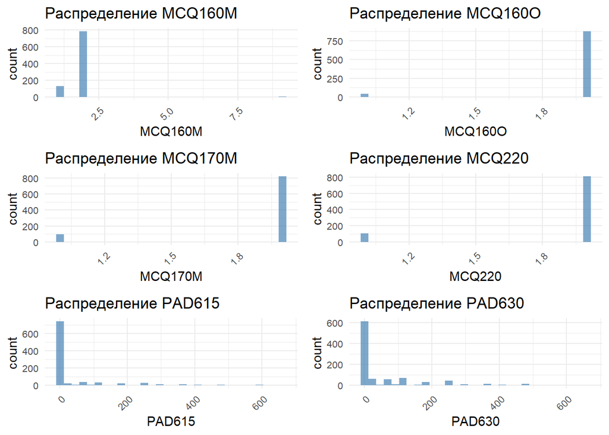

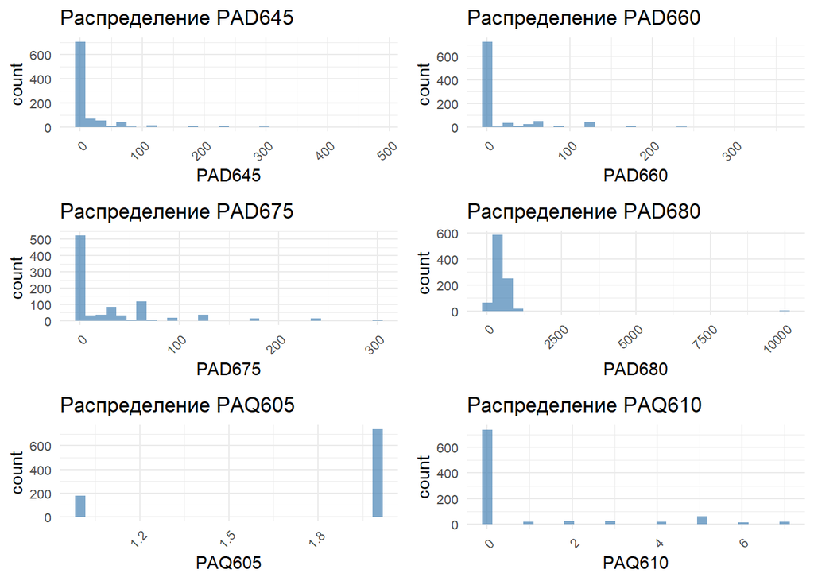

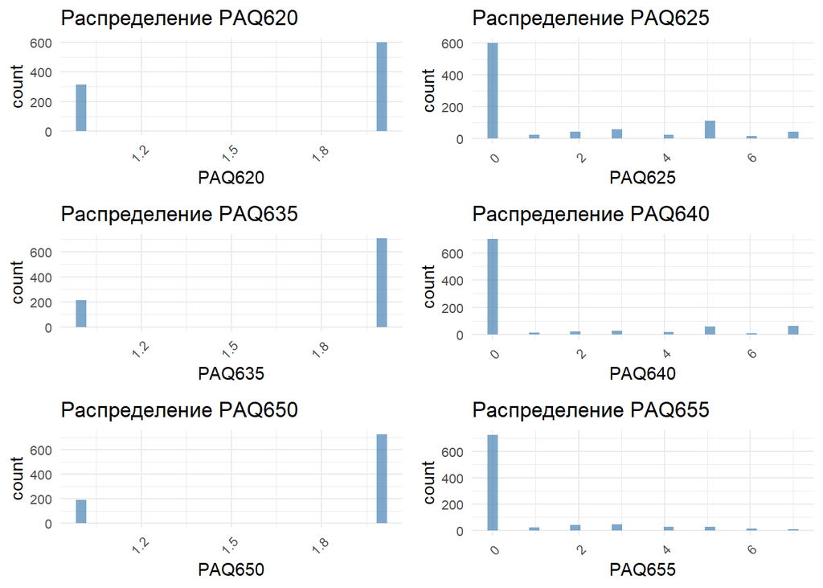

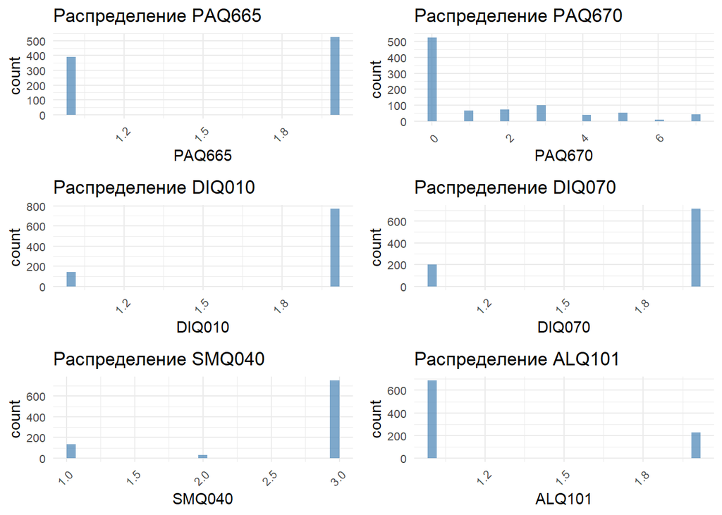

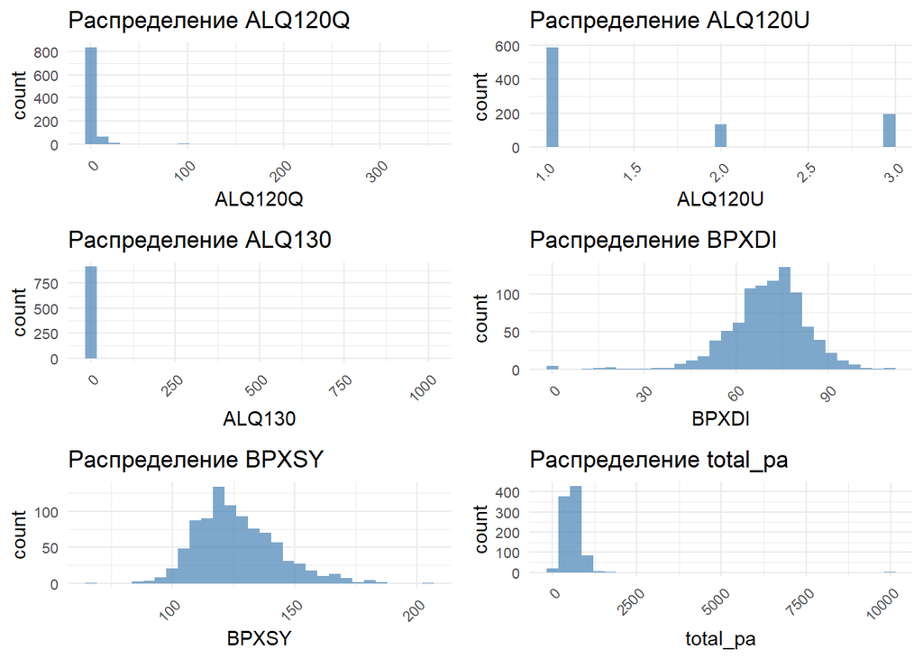

## Корреляционный анализ (Шаг 4)

Строим матрицу корреляций cor(), визуализируем corrplot. При необходимости проверяем корреляцию между ключевыми признаками, например, total_pa и LBXGH.

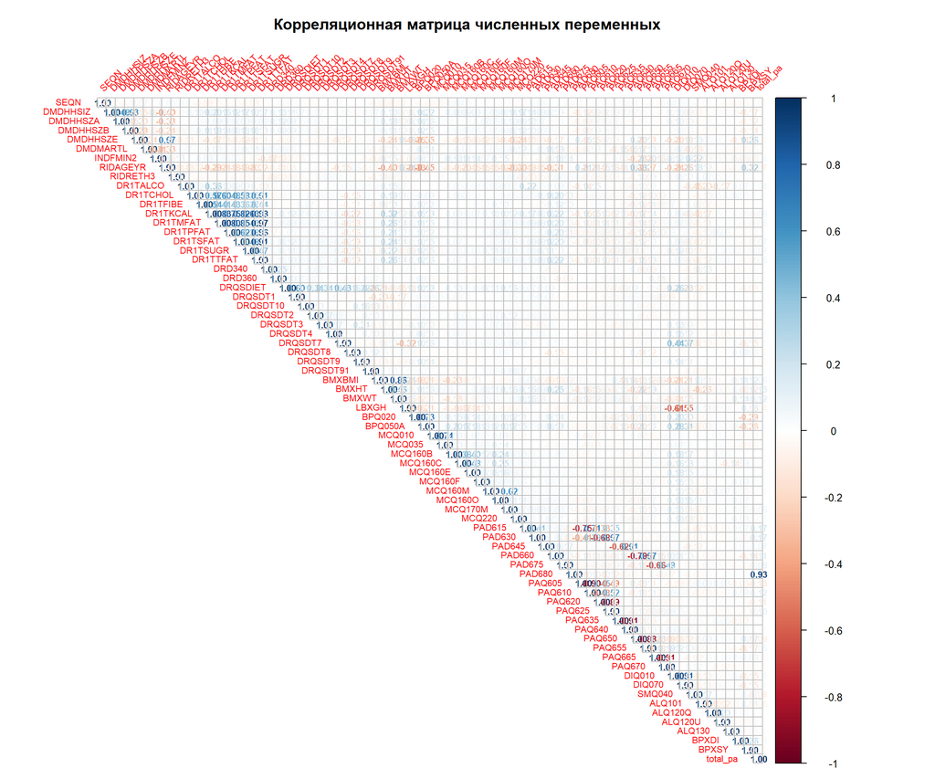

```
##
## Корреляция между total_pa и HbA1c (LBXGH): r = -0.04 , p-value = 0.2262336
```

## Анализ DAG-диаграммы

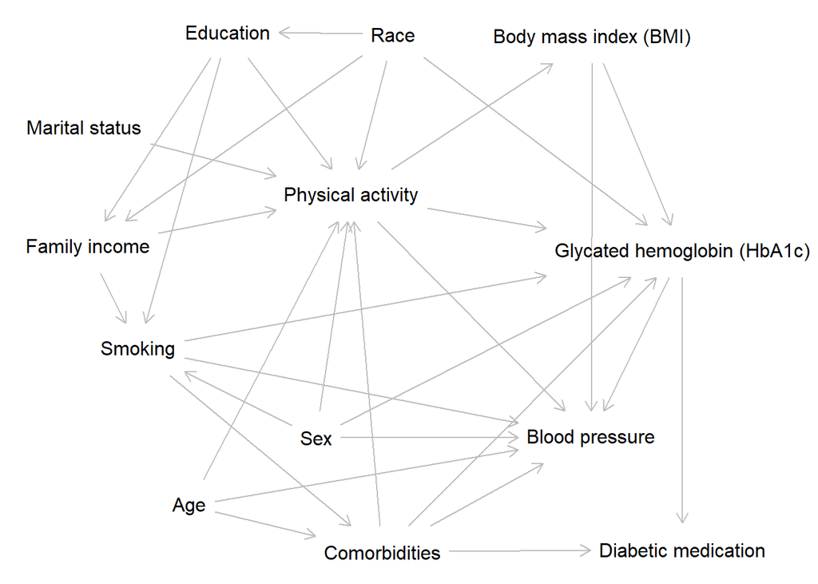

```
##
## Минимальные наборы для корректировки (DAGitty):
```

```
## { Comorbidities, Race, Sex, Smoking }
## { Age, Comorbidities, Education, Family income, Race, Sex }
```

## 6. Построение регрессионных моделей и вычисление информационных характеристик

# 7. Сравнение моделей по информационным критериям

```
##
## Сравнение информационных критериев:
```

```
##        Label                                                            Model
## 1   Adjusted  lm(formula = LBXGH ~ total_pa + RIDAGEYR + RIAGENDR + BMXBMI +
## 2   Adjusted                       SMQ020 + DMDEDUC2 + INDFMIN2, data = data)
## 3       Poly  lm(formula = LBXGH ~ total_pa + poly(RIDAGEYR, 2) + RIAGENDR +
## 4       Poly     poly(BMXBMI, 2) + SMQ020 + DMDEDUC2 + INDFMIN2, data = data)
## 5 Unadjusted                      lm(formula = LBXGH ~ total_pa, data = data)
## 6        PLS                                                              PLS
##        AIC      BIC          R2      RMSE
## 1 2572.320 2630.160 0.116305110 0.9783443
## 2 2572.320 2630.160 0.116305110 0.9783443
## 3 2573.642 2641.122 0.118884701 0.9779965
## 4 2573.642 2641.122 0.118884701 0.9779965
## 5 2666.109 2680.569 0.001601765 1.0347695
## 6       NA       NA 0.104024969 1.0359942
```

[output not shown]

[output not shown]

## 8 Диагностика выбранной модели

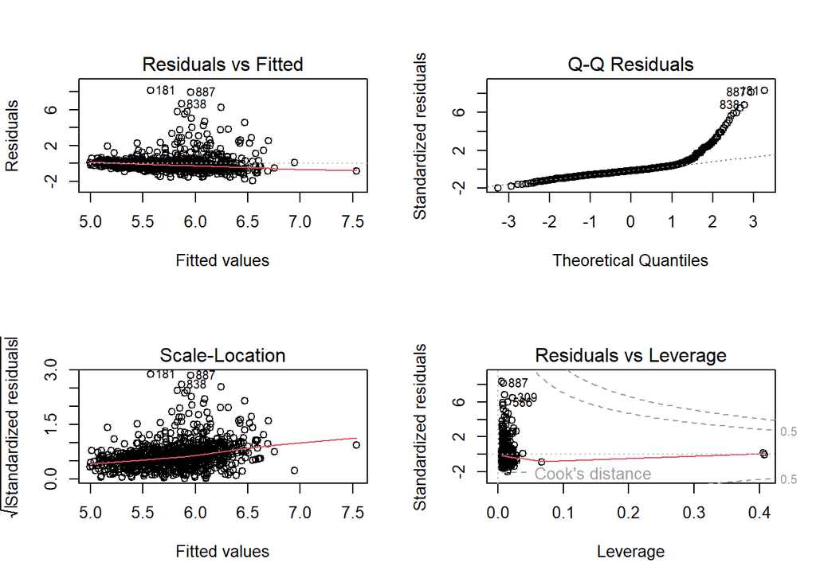

```
##
## VIF для модели с ковариатами:
```

```
##              GVIF Df GVIF^(1/(2*Df))
## total_pa 1.035510  1        1.017600
## RIDAGEYR 1.182406  1        1.087385
## RIAGENDR 1.207574  1        1.098897
## BMXBMI   1.029247  1        1.014518
## SMQ020   1.088079  1        1.043110
## DMDEDUC2 1.343780  4        1.037626
## INDFMIN2 1.298856  1        1.139674
```

```
##
## Тест Бройша-Пагана:
```

```
##
##  studentized Breusch-Pagan test
##
## data:  model_adjusted
## BP = 11.201, df = 10, p-value = 0.3421
```

```
## Вывод: не обнаружено серьёзных признаков гетероскедастичности.
```

## 9. Оценка результатов и проверка гипотез

```
##
## Эффект физической активности (total_pa) в модели с ковариатами:
```

```
## # A tibble: 1 × 7
##   term       estimate std.error statistic p.value  conf.low conf.high
##   <chr>         <dbl>     <dbl>     <dbl>   <dbl>     <dbl>     <dbl>
## 1 total_pa -0.0000796 0.0000661     -1.20   0.229 -0.000209 0.0000502
```

```
## p = 0.2290029 >= 0.05  => нет оснований отвергнуть H0, связь не статистически значима.
```

```
## Изменение < 0.5% => эффект, вероятно, незначим клинически.
```

## 10. Анализ взаимодействия (пол — модификатор)

```
##
## Модель с взаимодействием (пол):
```

```
##
## Call:
## lm(formula = LBXGH ~ total_pa * RIAGENDR + RIDAGEYR + BMXBMI +
##     SMQ020, data = data)
##
## Residuals:
##     Min      1Q  Median      3Q     Max
## -1.9886 -0.4631 -0.1733  0.1514  8.1111
##
## Coefficients:
##                           Estimate Std. Error t value Pr(>|t|)
## (Intercept)              4.013e+00  1.870e-01  21.461  < 2e-16 ***
## total_pa                -6.166e-05  6.873e-05  -0.897    0.370
## RIAGENDRFemale           9.434e-02  1.455e-01   0.649    0.517
## RIDAGEYR                 1.546e-02  2.131e-03   7.253 8.70e-13 ***
## BMXBMI                   3.369e-02  4.855e-03   6.940 7.45e-12 ***
## SMQ020Yes                5.804e-02  6.566e-02   0.884    0.377
## total_pa:RIAGENDRFemale -3.677e-04  2.441e-04  -1.506    0.132
## ---
## Signif. codes:  0 '***' 0.001 '**' 0.01 '*' 0.05 '.' 0.1 ' ' 1
##
## Residual standard error: 0.9812 on 909 degrees of freedom
## Multiple R-squared:  0.1072, Adjusted R-squared:  0.1013
## F-statistic: 18.19 on 6 and 909 DF,  p-value: < 2.2e-16
```

```
## p = 0.1323302 >= 0.05 => нет статистически значимого взаимодействия.
```

## 11 PSM, ATT и т.д.

```
##
## ATT (разница HbA1c между группами низкой/высокой ФА после матчинга):
```

```
## # A tibble: 2 × 7
##   term        estimate std.error statistic p.value conf.low conf.high
##   <chr>          <dbl>     <dbl>     <dbl>   <dbl>    <dbl>     <dbl>
## 1 (Intercept)    5.90     0.0483    122.   0          5.81     6.00
## 2 pa_binary     -0.196    0.0683     -2.87 0.00416   -0.330   -0.0621
```

## 12. Заключение

Основные выводы:

```
## Основные выводы:
```

```
## 1. По результатам сравнения информационных критериев лучшей (по AIC) оказалась модель:
```

[output not shown]

```
##    - lm(formula = LBXGH ~ total_pa + RIDAGEYR + RIAGENDR + BMXBMI +      SMQ020 + DMDEDUC2 + INDFMIN2, data = data)
```

```
## 2. Гипотеза об отсутствии ассоциации между ФА и HbA1c (H0: β=0) была не отвергнута (p-value = 0.2290029 ).
```

```
## 3. Проверка взаимодействия с полом показала, что нет статистически значимой модификации эффекта.
```

```
## 4. Клиническая значимость эффекта: при коэффициенте ~ 0 и принятом пороге 0.5% - не достигается .
```

Основные выводы: 1. По результатам сравнения информационных критериев лучшей (по AIC) оказалась модель: - Adjusted Adjusted 2. Гипотеза об отсутствии ассоциации между ФА и HbA1c (H0: β=0) была не отвергнута (p-value = 0.2290029 ). 3. Проверка взаимодействия с полом показала, что нет статистически значимой модификации эффекта. 4. Клиническая значимость эффекта: при коэффициенте ~ 0 и принятом пороге 0.5% - не достигается .